# UCell Analysis Tutorial on Cricket Spatial Data

Luis Martin Pena

2025-05-15

## 1. Load Required Libraries

```r
library(UCell)
library(Matrix)
library(Seurat)
library(dplyr)
library(readr)
library(stringr)
library(ggplot2)
library(jsonlite)
library(png)
```

## 2. Set Paths and Load Seurat Object from load_data.R

```r
base_path <- "../../datashare/grillus"
data_path <- file.path(base_path, "files")
output_dir <- file.path("..", "results", "ucell")
if (!dir.exists(output_dir)) dir.create(output_dir, recursive = TRUE)

seurat_obj <- readRDS(file.path(base_path, "grillus_seurat.rds"))
```

## 3. Load Gene Signatures from CSV Files.

- In this section we add labels to every functional annotation found in external files reference-based annotation from different studies (Pathways, metabolic process, epigenetic regulations, differentiation and regeneration-related functions.)
- For homogenizing the data we convert every gene name into the same index format. Since the latest version of Seurat (V5) is unable to add new specific layers into the metadata we will add this layer of information in @misc

```r
read_gene_list <- function(file, gene_col = 1) {
  df <- read_csv(file)
  genes <- df[[gene_col]]
  tolower(str_trim(gsub("_", "-", as.character(genes))))
}

genes_growth     <- read_gene_list(file.path(data_path, "de_gene_names_growth.csv"), gene_col = "gene_id")
genes_regen_up   <- read_gene_list(file.path(data_path, "ur_regeneration.csv"), gene_col = "gene_name")
genes_regen_down <- read_gene_list(file.path(data_path, "dr_regeneration.csv"), gene_col = "gene_name")
genes_scarring   <- read_gene_list(file.path(data_path, "gene_name_scaring.csv"), gene_col = "gene_id")

# Annotate gene features
gene_annot <- seurat_obj@misc$gene_annotations

add_flag <- function(genes) rownames(gene_annot) %in% genes

gene_annot$growth_gene     <- add_flag(genes_growth)
gene_annot$regen_up_gene   <- add_flag(genes_regen_up)
gene_annot$regen_down_gene <- add_flag(genes_regen_down)
gene_annot$scarring_gene   <- add_flag(genes_scarring)

seurat_obj@misc$gene_annotations <- gene_annot
```

## 4. Calculate UCell Scores for CSV Gene Sets

- Refer to Ucell Score documentation for detail ( https://github.com/carmonalab/UCell).
- We will get for the first analysis the 4 functional categories as signatures for our score in default parameters, we should see differentiated regions in the tissue even if high absolute scores are not expected.

```r
rownames(seurat_obj@meta.data) <- Cells(seurat_obj)
signatures <- list(
  growth     = rownames(gene_annot)[gene_annot$growth_gene],
  regen_up   = rownames(gene_annot)[gene_annot$regen_up_gene],
  regen_down = rownames(gene_annot)[gene_annot$regen_down_gene],
  scarring   = rownames(gene_annot)[gene_annot$scarring_gene]
)

for (sig in names(signatures)) {
  seurat_obj <- AddModuleScore_UCell(
    seurat_obj,
    features = signatures,
    name = "UCell"
  )
}
```

## 5. Load and Attach Spatial

- For a 10xVisium default data set we should charge the image with the Read10x function and then adding it as a layer in our object (key = image, spatial assay), any other image specification will result in an error.

```r
spatial_path <- file.path(base_path, "outs", "spatial")
img_obj <- Read10X_Image(image.dir = spatial_path, filter.matrix = TRUE)

# key and assay
img_obj@key <- "image_"
img_obj@assay <- "Spatial"

# add image
seurat_obj[["image"]] <- img_obj
DefaultAssay(seurat_obj) <- "Spatial"

# Verif
Images(seurat_obj)
```

```
## [1] "image"
```

## 6. Visualize UCell Scores

- First test for plotting, heatmap score.

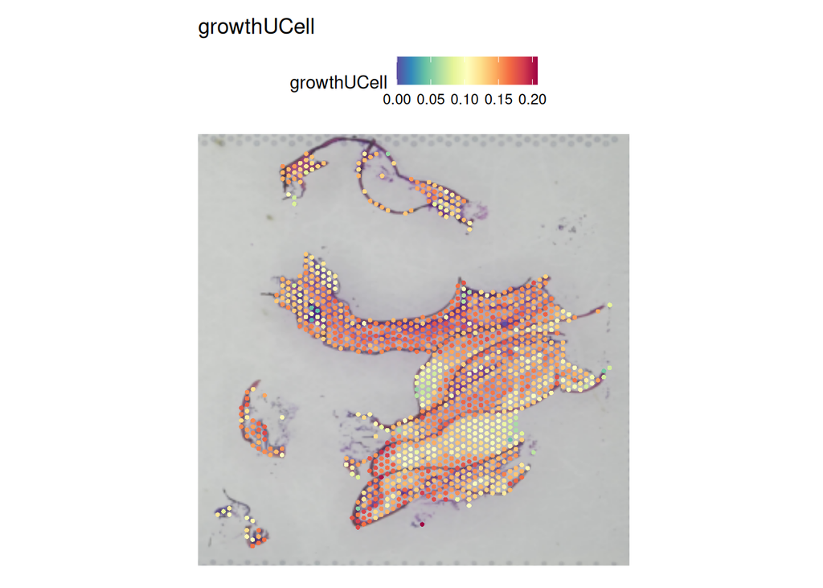

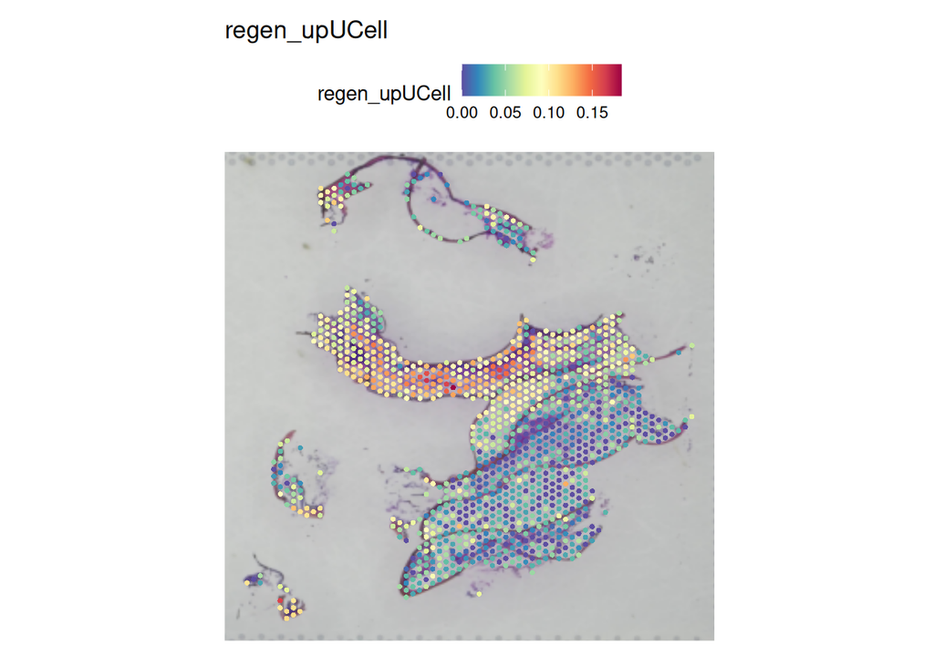

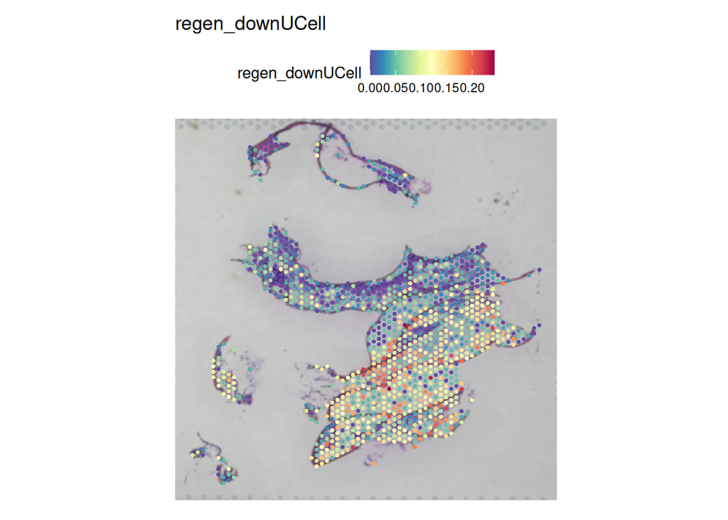

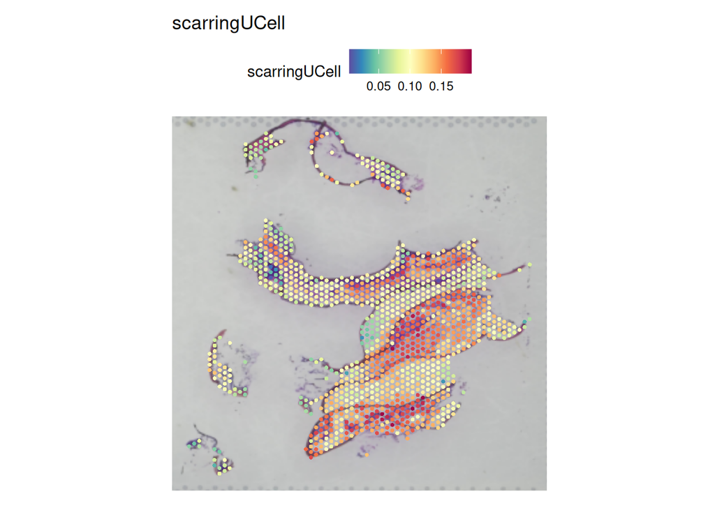

```r
features_to_plot <- c("growthUCell", "regen_upUCell", "regen_downUCell", "scarringUCell")

for (feat in features_to_plot) {
  p <- SpatialFeaturePlot(
    seurat_obj,
    features = feat,
    pt.size.factor = 3
  ) + ggtitle(feat)

  print(p)

  ggsave(
    filename = file.path(output_dir, paste0(feat, ".png")),
    plot = p,
    width = 6,
    height = 6,
    dpi = 300
  )
}
```

## 7. Additional Gene Sets from PDF (Pathways & Regulators)

```r
# Example manually annotated gene sets from database list (mapped to gene IDs beforehand)

# Convert gene names to IDs
gene_dict <- read_csv(file.path(data_path, "liste_gene_and_code.csv")) %>%
  mutate(
    gene_name = tolower(str_trim(gene_name)),
    gene_id   = tolower(str_replace_all(str_trim(gene_id), "_", "-"))  # 🔥 la línea clave
  )

# Signaling
genes_hedgehog     <- c("su(fu)", "ptr")
genes_egfr         <- c("spi", "phl", "rl", "mkp3", "kay")
genes_dpp          <- c("mav", "actβ", "myoglianin", "put", "mad", "bun")
genes_vegf         <- c("pvr", "pvf1")
genes_insulin_igf  <- c("inr", "pten")
genes_notch        <- c("n", "sno")
genes_toll         <- c("spz", "toll-9", "tl", "18w", "rel", "dl")

# TFs
genes_tfs <- c("ets21c", "ab", "mtf-1", "hr4", "sima", "p53", "vri", "runxb", "jra", "myb", "zfh1", "lz")

# Epigenetic regulation
genes_methyl_histone   <- c("utx", "lid", "trx", "pc")
genes_acetyl_histone   <- c("cg14220", "enok", "hdac4", "hdac6")
genes_chrom_remodeling <- c("etl1", "snr1", "mor")
genes_dna_methylation  <- c("dmap1")

# Set ID
map_to_ids <- function(gene_names) {
  gene_dict %>%
    filter(gene_name %in% gene_names) %>%
    pull(gene_id) %>%
    unique()
}

# Save list
ids_hedgehog     <- map_to_ids(genes_hedgehog)
ids_egfr         <- map_to_ids(genes_egfr)
ids_dpp          <- map_to_ids(genes_dpp)
ids_vegf         <- map_to_ids(genes_vegf)
ids_insulin_igf  <- map_to_ids(genes_insulin_igf)
ids_notch        <- map_to_ids(genes_notch)
ids_toll         <- map_to_ids(genes_toll)
ids_tfs          <- map_to_ids(genes_tfs)
ids_methyl_hist  <- map_to_ids(genes_methyl_histone)
ids_acetyl_hist  <- map_to_ids(genes_acetyl_histone)
ids_remodeling   <- map_to_ids(genes_chrom_remodeling)
ids_dna_methyl   <- map_to_ids(genes_dna_methylation)

# Verify
sapply(list(
  Hedgehog = ids_hedgehog,
  EGFR = ids_egfr,
  Dpp_TGFb = ids_dpp,
  VEGF = ids_vegf,
  Insulin_IGF = ids_insulin_igf,
  Notch = ids_notch,
  Toll = ids_toll,
  TFs = ids_tfs,
  Methyl_Histone = ids_methyl_hist,
  Acetyl_Histone = ids_acetyl_hist,
  Chromatin_Remodeling = ids_remodeling,
  DNA_Methylation = ids_dna_methyl
), function(x) sum(x %in% rownames(seurat_obj)))
```

```
##             Hedgehog                 EGFR             Dpp_TGFb
##                    0                    5                    2
##                 VEGF          Insulin_IGF                Notch
##                    0                    2                    7
##                 Toll                  TFs       Methyl_Histone
##                    5                    4                    5
##       Acetyl_Histone Chromatin_Remodeling      DNA_Methylation
##                    0                    1                    0
```

```r
# Set positive signatures
signatures_interest <- list(
  EGFR                 = ids_egfr,
  Dpp_TGFb             = ids_dpp,
  Insulin_IGF          = ids_insulin_igf,
  Notch                = ids_notch,
  Toll                 = ids_toll,
  TFs                  = ids_tfs,
  Methyl_Histone       = ids_methyl_hist,
  Chromatin_Remodeling = ids_remodeling
)
gene_annot <- seurat_obj@misc$gene_annotations

# Save in metadata
for (sig in names(signatures_interest)) {
  gene_annot[[sig]] <- rownames(gene_annot) %in% signatures_interest[[sig]]
}

# Verify
seurat_obj@misc$gene_annotations <- gene_annot
sapply(gene_annot[names(signatures_interest)], sum)
```

```
##                 EGFR             Dpp_TGFb          Insulin_IGF
##                    5                    2                    2
##                Notch                 Toll                  TFs
##                    7                    5                    4
##       Methyl_Histone Chromatin_Remodeling
##                    5                    1
```

```r
# Get Ucell score
for (sig in names(signatures_interest)) {
  seurat_obj <- AddModuleScore_UCell(
    seurat_obj,
    features = list(signatures_interest[[sig]]),
    name = paste0(sig, "_UCell")
  )
}
```

## 8. Visualize database-Informed Scores

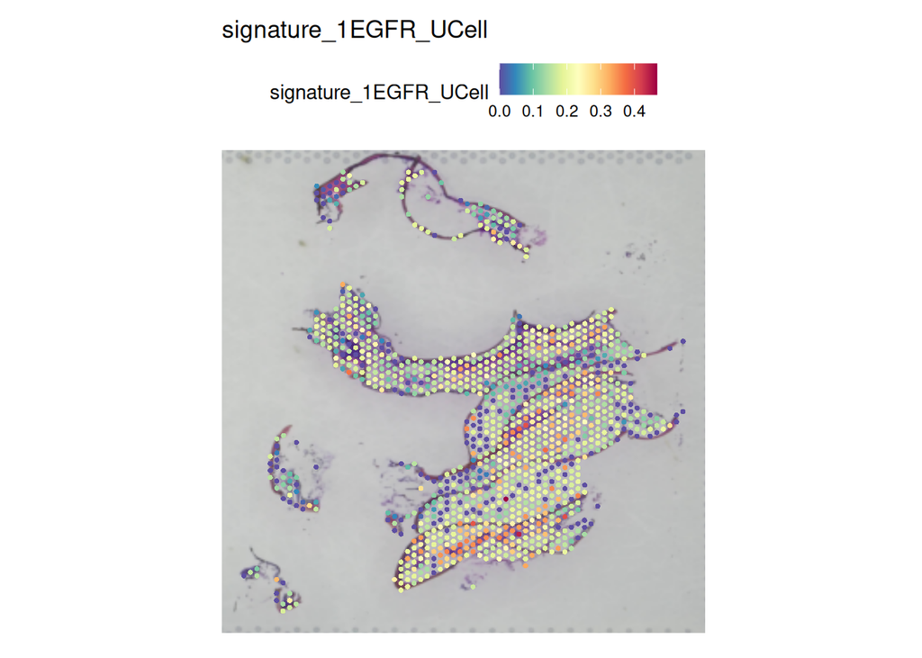

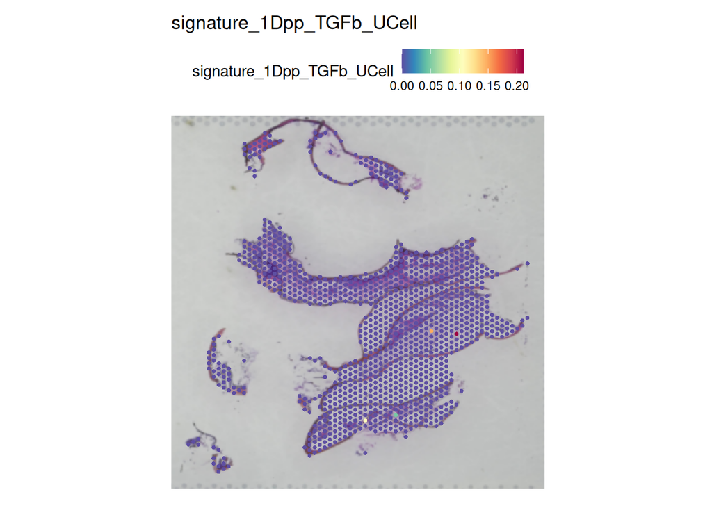

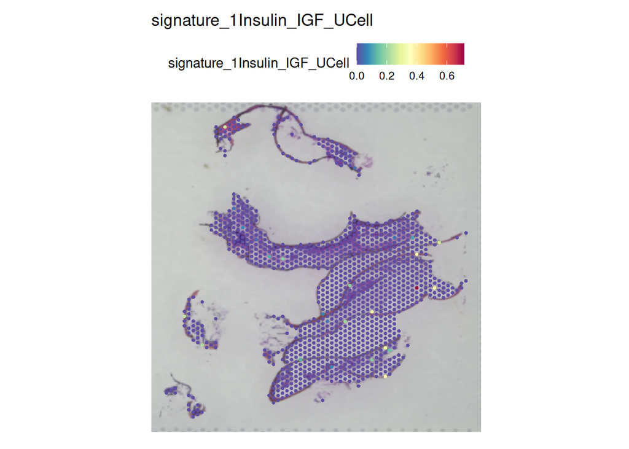

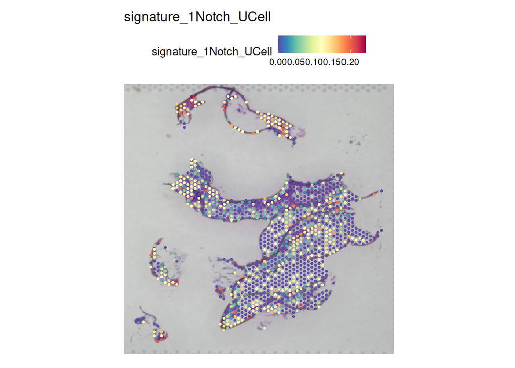

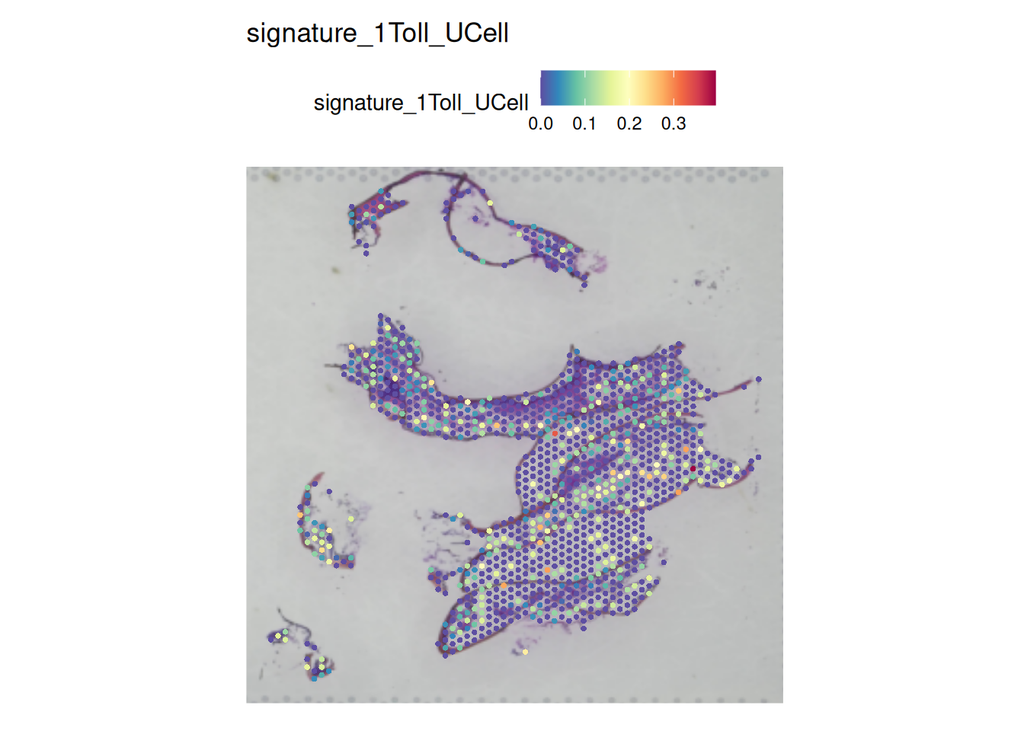

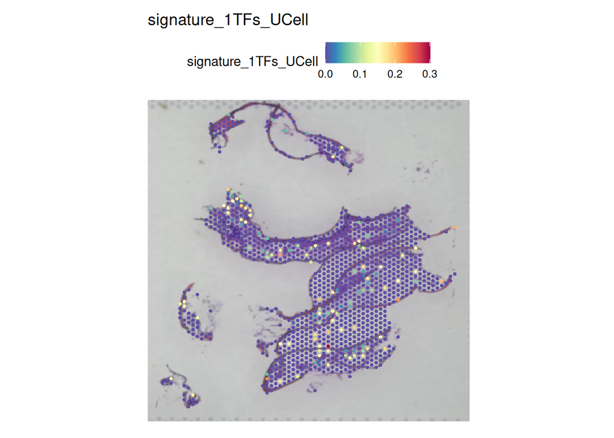

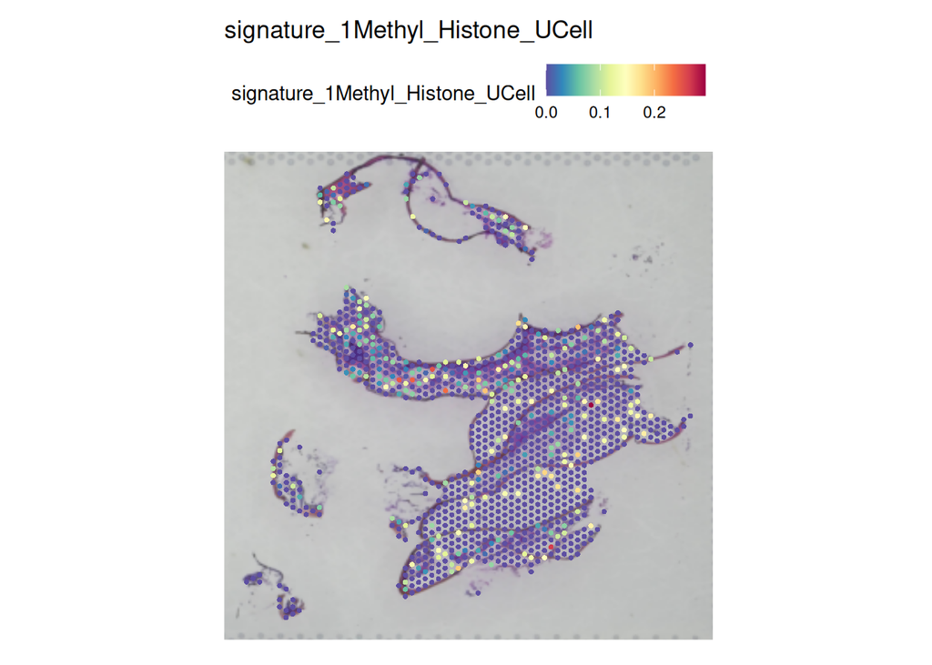

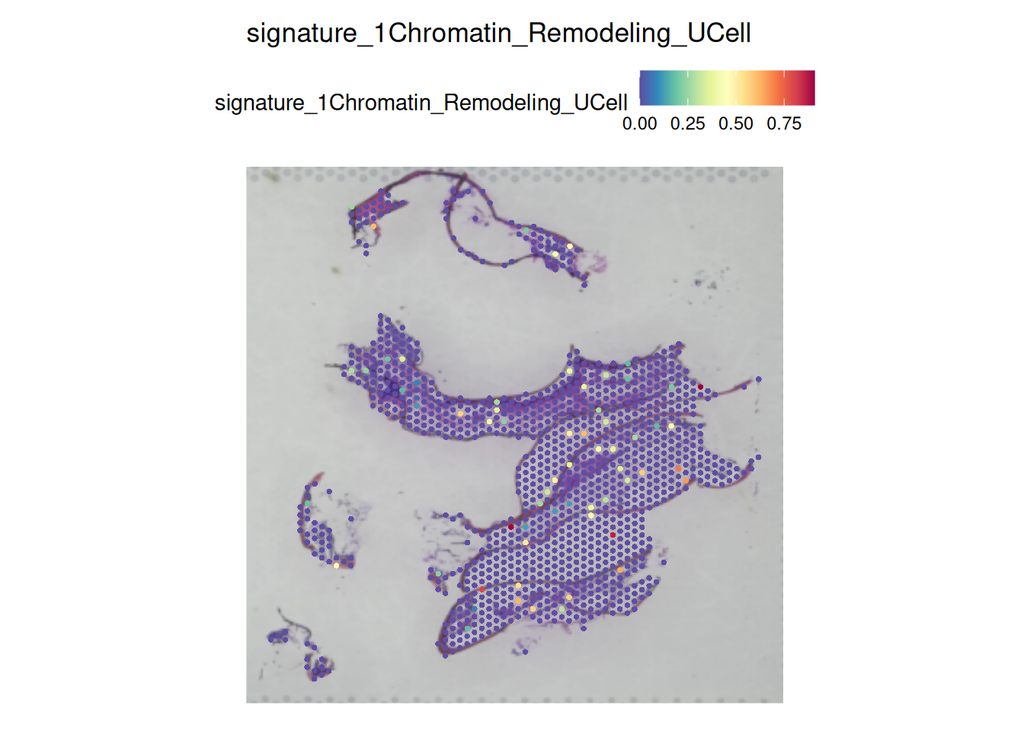

```r
ucell_feats <- grep("_UCell$", colnames(seurat_obj@meta.data), value = TRUE)

for (feat in ucell_feats) {
  p <- SpatialFeaturePlot(
    seurat_obj,
    features = feat,
    pt.size.factor = 3
  ) + ggtitle(feat)

  print(p)

  ggsave(
    filename = file.path(output_dir, paste0(feat, ".png")),
    plot = p,
    width = 6,
    height = 6,
    dpi = 300
  )
}
```

## 10.1 Visualize database-Informed Scores (Binary)

- Extra visualization for binary maps with a custom threshold, here 0.15 for TRUE.

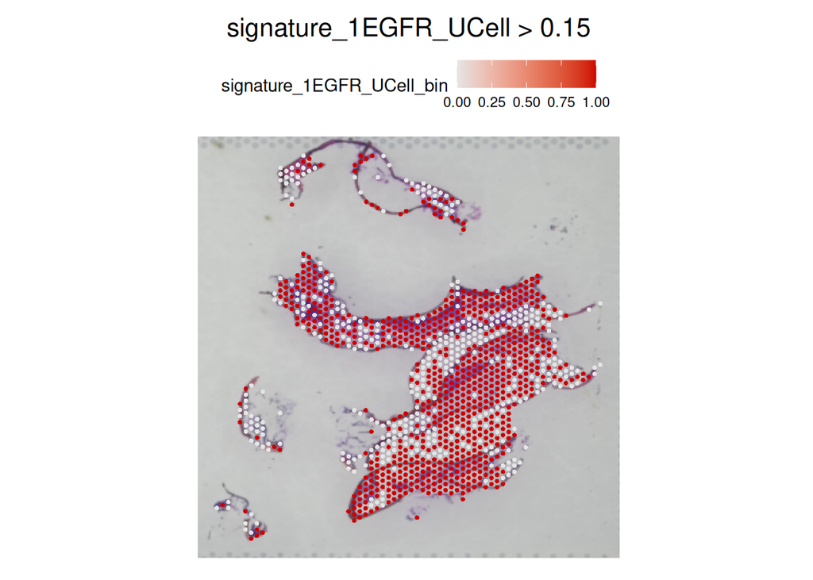

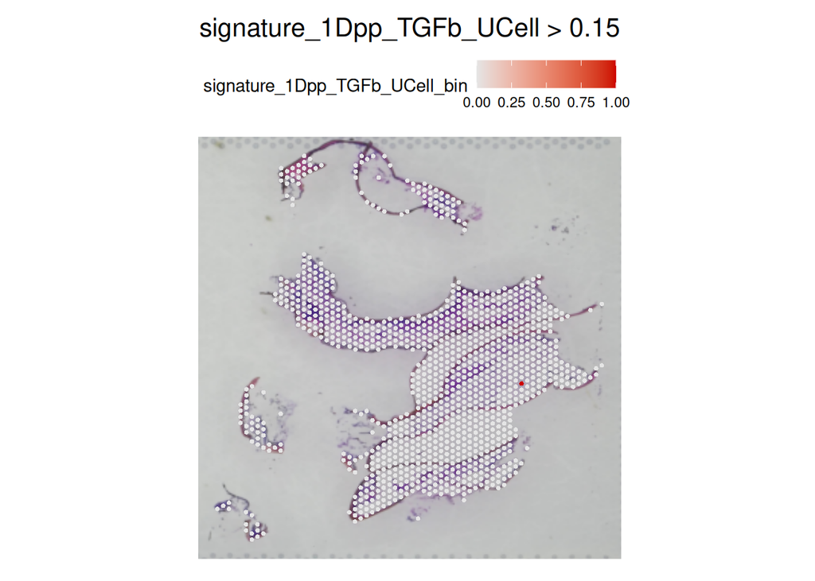

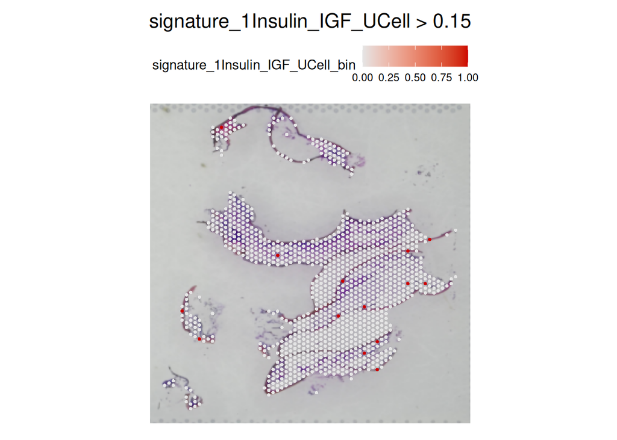

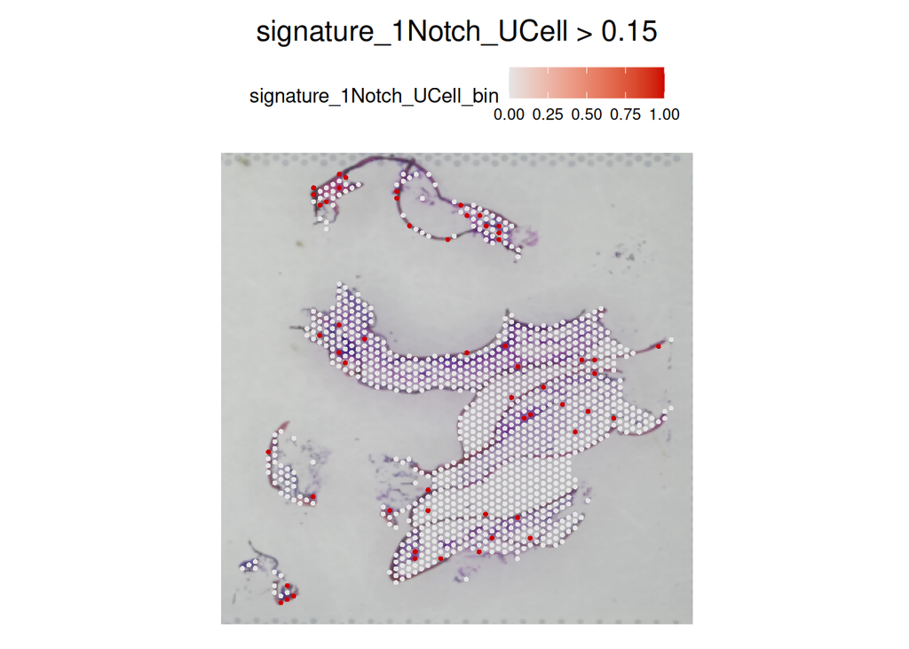

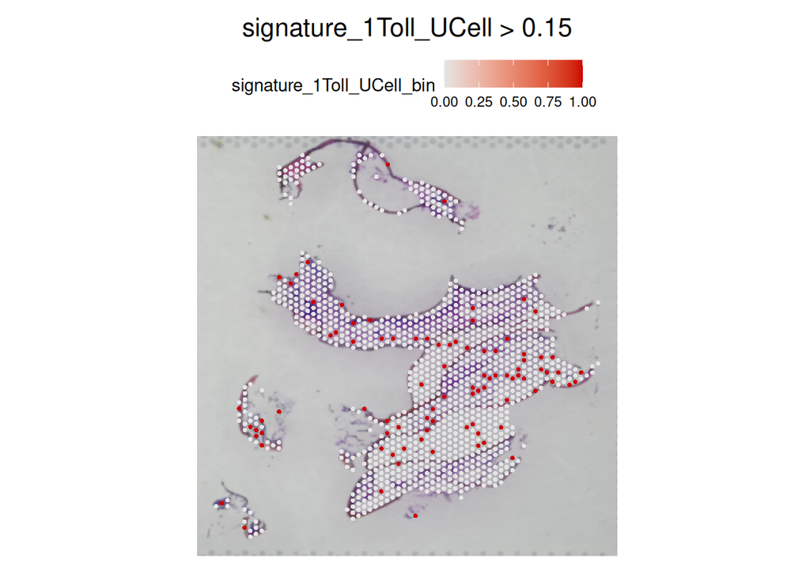

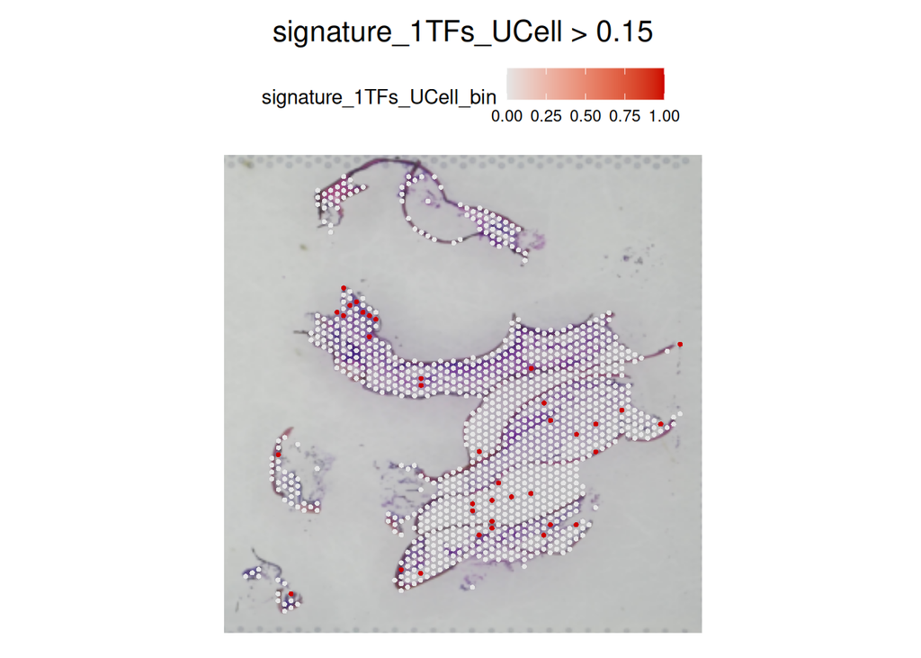

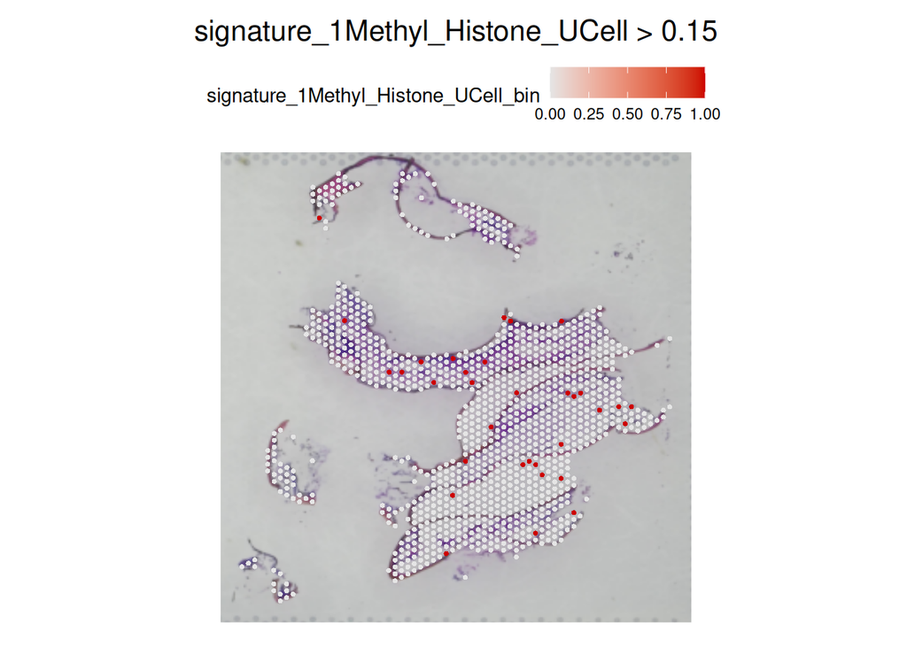

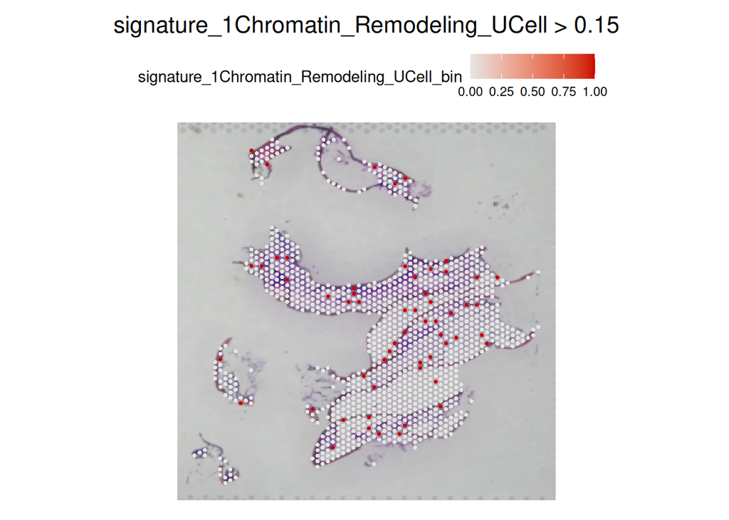

```r
binary_dir <- file.path(output_dir, "binary")
if (!dir.exists(binary_dir)) dir.create(binary_dir)

# Set Threshold
threshold <- 0.15

for (feat in ucell_feats) {
  bin_col <- paste0(feat, "_bin")

  seurat_obj@meta.data[[bin_col]] <- as.numeric(seurat_obj@meta.data[[feat]] > threshold)

  # Binary plot
  p <- SpatialFeaturePlot(
    seurat_obj,
    features = bin_col,
    pt.size.factor = 3
  ) +
    scale_fill_gradientn(
      colours = c("grey90", "red3"),
      limits = c(0, 1)
    ) +
    ggtitle(paste0(feat, " > ", threshold)) +
    theme(plot.title = element_text(hjust = 0.5, size = 16))

  print(p)

  ggsave(
    filename = file.path(binary_dir, paste0(feat, "_binary.png")),
    plot = p,
    width = 6,
    height = 6,
    dpi = 300
  )
}
```

- Extra visualization for binary maps with a custom threshold, here 0.10 for TRUE.

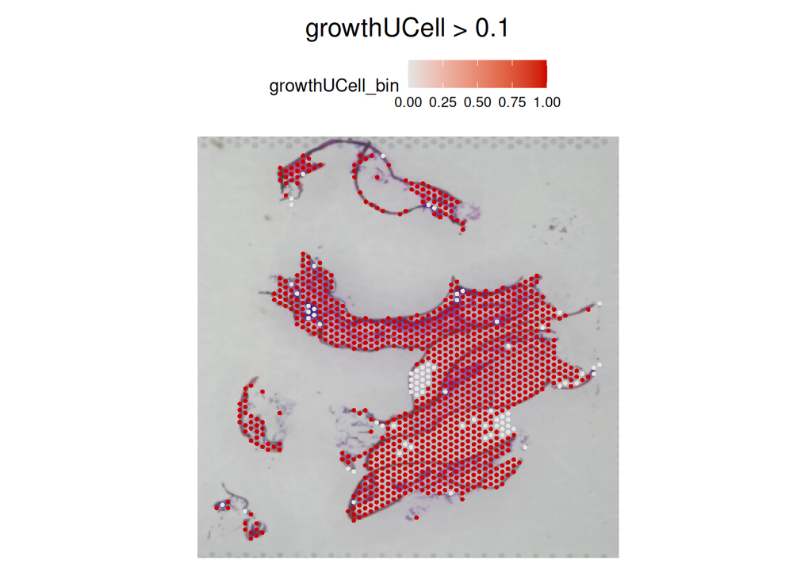

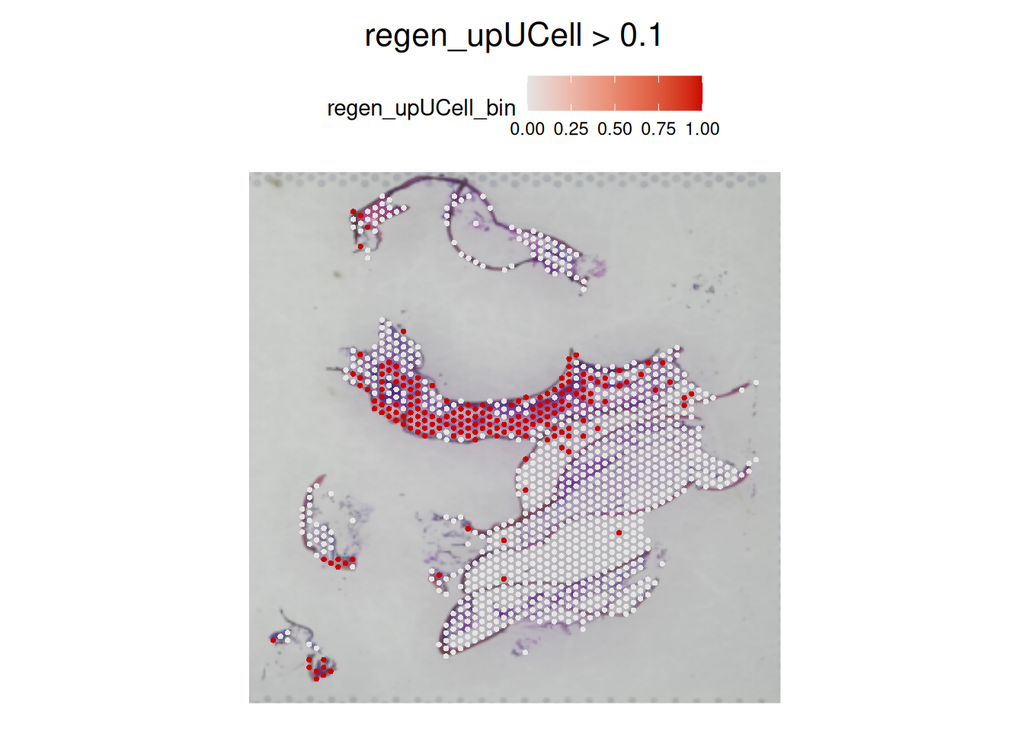

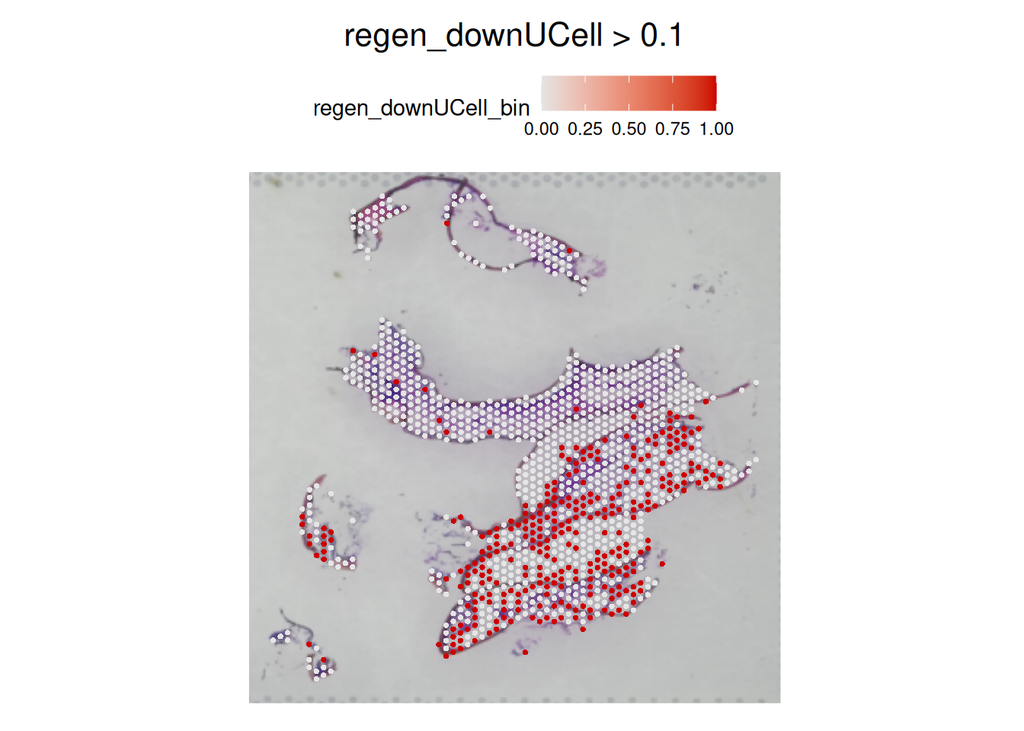

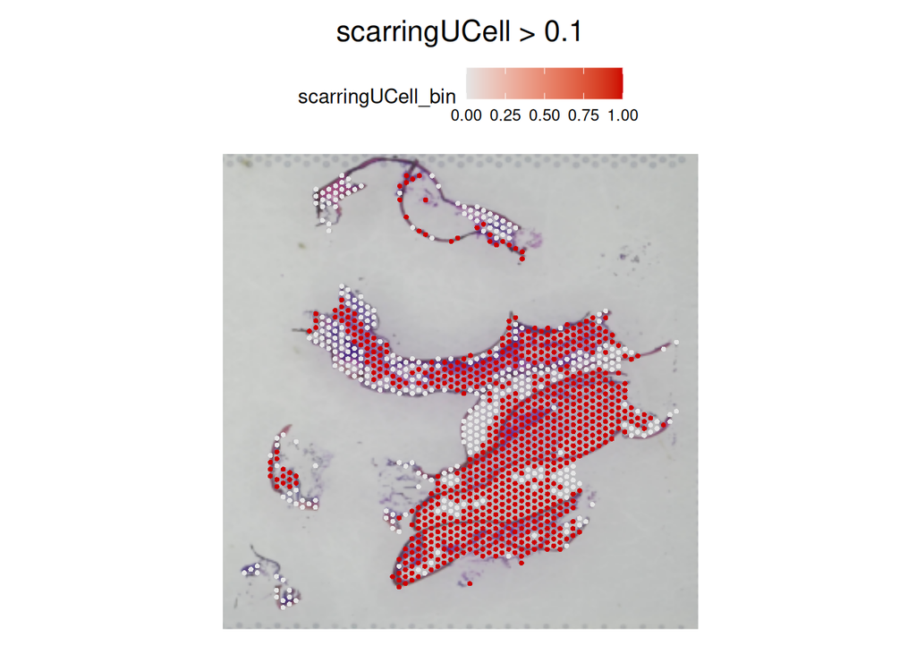

```r
# Binary regions
features_to_plot <- c("growthUCell", "regen_upUCell", "regen_downUCell", "scarringUCell")

# SET THRESHOLD
threshold <- 0.10

# FIGURES
for (feat in features_to_plot) {
  bin_col <- paste0(feat, "_bin")

  # create binary column
  seurat_obj@meta.data[[bin_col]] <- as.numeric(seurat_obj@meta.data[[feat]] > threshold)

  # simple scale binary
  p <- SpatialFeaturePlot(
    seurat_obj,
    features = bin_col,
    pt.size.factor = 3
  ) +
    scale_fill_gradientn(
      colours = c("grey90", "red3"),
      limits = c(0, 1)
    ) +
    ggtitle(paste0(feat, " > ", threshold)) +
    theme(plot.title = element_text(hjust = 0.5, size = 16))

  print(p)

  ggsave(
    filename = file.path(binary_dir, paste0(feat, "_binary.png")),
    plot = p,
    width = 6,
    height = 6,
    dpi = 300
  )
}
```

## 11. Save Final Seurat Object

```r
saveRDS(seurat_obj, file.path(base_path, "grillus_seurat_ucell_final.rds"))
```

**Note:** Gene IDs are placeholders; replace with real mapped values when running on your dataset.

**Next Steps:** - Add biological interpretation layers - Cross-species ontology mapping (e.g., via FlyBase, GO) - Combine UCell with clustering or region segmentation